# One4All_LA8

Braden Griebel, Luke Fanning, Andrew Duffy, Ahyo Falick

10/16/2019

# Team Question:

We were highered by an public health specialist to determine the relationship between the level of industrialization (measured by electricity, natural gas, and oil consumption as well as industrial production growth rate) affect various measures of population health, such as death rate, infant mortality and life expectancy. This will help illuminate the relationship between industrialization and health. Understanding this relationship will help to guide policies about how indistrialization is encouraged or discouraged in different areas, in order to increase the general health of the populace.

A data set that could help answer this question is loaded below, it is a factbook with data on 160 countries, and ~100 non-country political entities. Across these countries it has 44 measurements, including debt, resource consumtion/production, internet users, life expectancy, fertility rates, and many more.

dataset:

```r
factbook<-read_delim("factbook.csv",delim=";",col_types = cols(
  Country=col_character(),
  `Area(sq km)`=col_double(),
  `Birth rate(births/1000 population)`=col_double(),
  `Current account balance`=col_double(),
  `Death rate(deaths/1000 population)`=col_double(),
  `Debt - external`=col_double(),
  `Electricity - consumption(kWh)`=col_double(),
  `Electricity - production(kWh)`=col_double(),
  `Exports`=col_double(),
  `GDP`=col_double(),
  `GDP - per capita`=col_double(),
  `GDP - real growth rate(%)`=col_double(),
  `HIV/AIDS - adult prevalence rate(%)`=col_double(),
  `HIV/AIDS - deaths`=col_double(),
  `HIV/AIDS - people living with HIV/AIDS`=col_double(),
  `Highways(km)`=col_double(),
  `Imports`=col_double(),
  `Industrial production growth rate(%)`=col_double(),
  `Infant mortality rate(deaths/1000 live births)`=col_double(),
  `Inflation rate (consumer prices)(%)`=col_double(),
  `Internet hosts`=col_double(),
  `Internet users`=col_double(),
  `Investment (gross fixed)(% of GDP)`=col_double(),
  `Labor force`=col_double(),
  `Life expectancy at birth(years)`=col_double(),
  `Military expenditures - dollar figure`=col_double(),
  `Military expenditures - percent of GDP(%)`=col_double(),
  `Natural gas - consumption(cu m)`=col_double(),
  `Natural gas - exports(cu m)`=col_double(),
  `Natural gas - imports(cu m)`=col_double(),
  `Natural gas - production(cu m)`=col_double(),
  `Natural gas - proved reserves(cu m)`=col_double(),
  `Oil - consumption(bbl/day)`=col_double(),
  `Oil - exports(bbl/day)`=col_double(),
  `Oil - imports(bbl/day)`=col_double(),
  `Oil - production(bbl/day)`=col_double(),
  `Oil - proved reserves(bbl)`=col_double(),
  `Population`=col_double(),
  `Railways(km)`=col_double(),
  `Public debt(% of GDP)`=col_double(),
  `Reserves of foreign exchange & gold`=col_double(),
  `Telephones - main lines in use`=col_double(),
  `Telephones - mobile cellular`=col_double(),
  `Total fertility rate(children born/woman)`=col_double(),
  `Unemployment rate(%)`=col_double()
))
factbook<-factbook[2:264,]
factbook
```

```
## # A tibble: 263 x 45
##    Country `Area(sq km)` `Birth rate(bir~ `Current accoun~ `Death rate(dea~
##    <chr>           <dbl>            <dbl>            <dbl>            <dbl>
##  1 Afghan~        647500             47.0               NA            20.8
##  2 Akroti~           123             NA                 NA            NA
##  3 Albania         28748             15.1       -504000000             5.12
##  4 Algeria       2381740             17.1      11900000000             4.6
##  5 Americ~           199             23.1               NA             3.33
##  6 Andorra           468              9                 NA             6.07
##  7 Angola        1246700             44.6        -37880000            25.9
##  8 Anguil~           102             14.3               NA             5.43
##  9 Antarc~      14000000             NA                 NA            NA
## 10 Antigu~           443             17.3               NA             5.44
## # ... with 253 more rows, and 40 more variables: `Debt - external` <dbl>,
## #   `Electricity - consumption(kWh)` <dbl>, `Electricity -
## #   production(kWh)` <dbl>, Exports <dbl>, GDP <dbl>, `GDP - per
## #   capita` <dbl>, `GDP - real growth rate(%)` <dbl>, `HIV/AIDS - adult
## #   prevalence rate(%)` <dbl>, `HIV/AIDS - deaths` <dbl>, `HIV/AIDS -
## #   people living with HIV/AIDS` <dbl>, `Highways(km)` <dbl>,
## #   Imports <dbl>, `Industrial production growth rate(%)` <dbl>, `Infant
## #   mortality rate(deaths/1000 live births)` <dbl>, `Inflation rate
## #   (consumer prices)(%)` <dbl>, `Internet hosts` <dbl>, `Internet
## #   users` <dbl>, `Investment (gross fixed)(% of GDP)` <dbl>, `Labor
## #   force` <dbl>, `Life expectancy at birth(years)` <dbl>, `Military
## #   expenditures - dollar figure` <dbl>, `Military expenditures - percent
## #   of GDP(%)` <dbl>, `Natural gas - consumption(cu m)` <dbl>, `Natural
## #   gas - exports(cu m)` <dbl>, `Natural gas - imports(cu m)` <dbl>,
## #   `Natural gas - production(cu m)` <dbl>, `Natural gas - proved
## #   reserves(cu m)` <dbl>, `Oil - consumption(bbl/day)` <dbl>, `Oil -
## #   exports(bbl/day)` <dbl>, `Oil - imports(bbl/day)` <dbl>, `Oil -
## #   production(bbl/day)` <dbl>, `Oil - proved reserves(bbl)` <dbl>,
## #   Population <dbl>, `Public debt(% of GDP)` <dbl>, `Railways(km)` <dbl>,
## #   `Reserves of foreign exchange & gold` <dbl>, `Telephones - main lines
## #   in use` <dbl>, `Telephones - mobile cellular` <dbl>, `Total fertility
## #   rate(children born/woman)` <dbl>, `Unemployment rate(%)` <dbl>
```

# Braden Griebel Individual Section:

## Question I will Answer Next Week

**Question 1**: What Factors have the greatest affect on the rate of HIV/AIDS in adults between various countries. This is interesting because understanding what affects the rate of HIV/AIDS will allow for a greater understanding of how it tends to be spread, and so institute policies that will reduce its spread. Not neccesarily by reducing something positively correlated with the rate, but by understanding why that variable is positively correlated with the rate of HIV/AIDS and instituting policies to decrease that factors relationship with HIV/AIDS. Thus, this is mostly just a jumpting off point in seeing what affects the rate of HIV/AIDS, and then using that to further explore why exactly this this affect this rate.

**Backup Question**: What is the relationship between length of highways and railroads, when controlling for land area and wealth measured by GDP per capita, and what affect does the ratio have with the oil consumption of the country? This is interesting because it will show if increasing the ratio of railways to higways has a significant affect on oil consumption, since trains and trucks have a significantly different fuel per ton of freight requirements so maybe the amount of railways would change the overall oil consumption of a country. This would possibly allow for countries to focus on constructing more of one or the other to reduce their overall oil consumption, which would both mean the country is spending less money on fuel, and producing lower amounts of carbon dioxide production. Reducing the carbon dioxide released could help with meeting emmision goals, and thus hopefully help reduce the rate of global climate change.

## East Africa Lake Data Lake Malawi

*It is unclear whether the BSi MAR is two seperate values. It seems that they are mostly different years, but there are some overlap of years with different values. So I graphed it two ways, first treating them as seperate vaariables then treating it as a single variable after I combined them. When combining them, I used the left most columns value when the two columns had different values that disagreed. There were not many of these values so it doesn’t affect the overall trend significantly. I graphed the BSi against calander year since that made the graph more intuitive to understand. Graphing it against age would mean having time go from right to left, which is more confusing.*

```r
malawi<-read_excel(path="East Africa lake data.xlsx",sheet="Malawi")
malawi<-malawi[-c(4,5)]
malawi1<-malawi[c(1:3)]
malawi2<-malawi[c(4:6)]
malawi1<-malawi1%>%select("age"=`Age, ybp`,"calender"=`Age (calender)...2`,"Bsi1"=`BSi MAR (mgSiO2/cm2y)...3`)
malawi2<-malawi2%>%select("age"=`Age, cal ybp`,"calender"=`Age (calender)...7`,"Bsi2"=`BSi MAR (mgSiO2/cm2y)...8`)
malawi1$age<-as.integer(malawi1$age)
malawi1$calender<-as.integer(malawi1$calender)
malawi2$age<-as.integer(malawi2$age)
malawi2$calender<-as.integer(malawi2$calender)
malawi1<-malawi1%>%filter(!is.na(age))
malawi2<-malawi2%>%filter(!is.na(age))


malawi<-full_join(malawi1,malawi2,by=c("calender","age"))
```

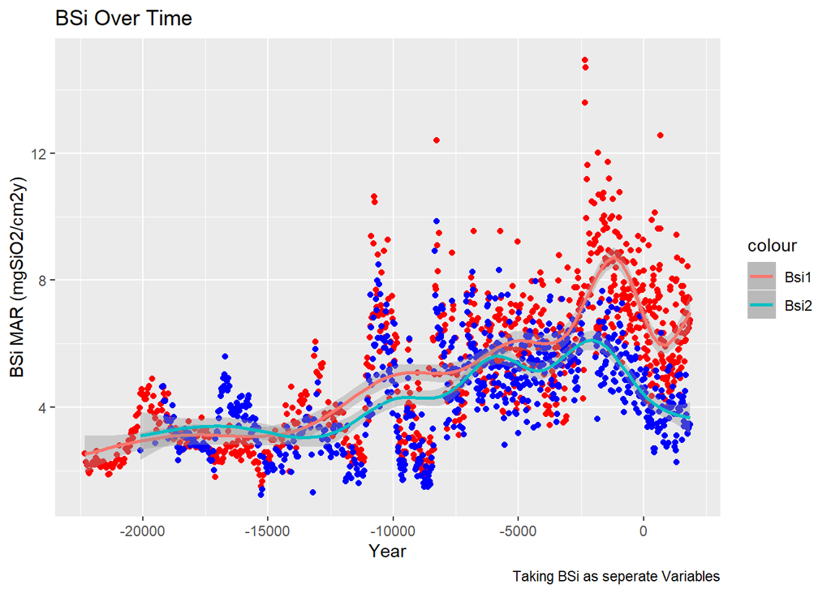

```r
ggplot(malawi,aes(calender))+geom_point(aes(y=Bsi1),color="red")+geom_point(aes(y=Bsi2),color="blue")+geom_smooth(aes(y=Bsi1,color="Bsi1"))+
  geom_smooth(aes(y=Bsi2,color="Bsi2"))+labs(x="Year",y="BSi MAR (mgSiO2/cm2y)",title="BSi Over Time",caption="Taking BSi as seperate Variables")
```

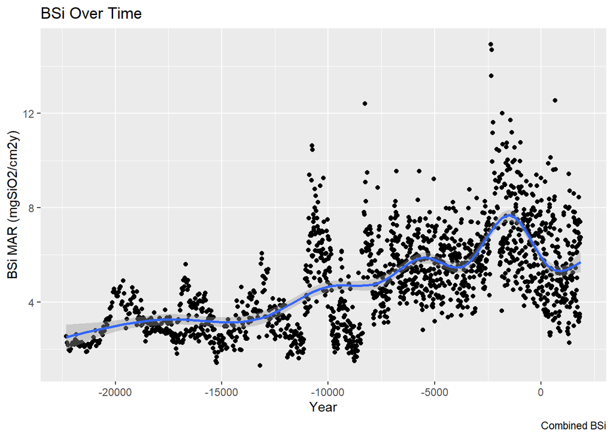

```r
malawi2<-malawi%>%unite(Bsi1,Bsi2,col="BSi",sep='_')
malawi3<-malawi2[917:1655,]%>%separate(BSi,into=c(NA,"BSi"),sep="_")
malawi4<-malawi2[1:916,]%>%separate(BSi,into=c("BSi",NA),sep="_")
malawi2<-full_join(malawi3,malawi4)
malawi2$BSi<-as.double(malawi2$BSi)
malawi2<-malawi2%>%filter(!is.na(BSi))
ggplot(data=malawi2,aes(calender,BSi))+geom_point()+geom_smooth()+labs(x="Year",y="BSi MAR (mgSiO2/cm2y)",title="BSi Over Time",
                                                                       caption="Combined BSi")
```